# Lecture Lab 9

Leon Eyrich Jessen, Daniel Romero

2026

# Creating a Simple Shiny App

## But… What is Shiny? …and how does it relate to a package?

*What if you wanted to “share your code” with someone who doesnt know how to code?* 🤔

[figure not shown]

- A package is an ordered and documented collection of functions

[figure not shown]

- A Shiny app is a web interface to interact with R functions in the browser

## General Idea is to…

- Shiny enables writing powerful interactive web apps in R, thereby:
  - Connecting non-data experts with data
  - Automating time consuming tasks
  - Showcasing data to relevant stakeholders
  - Generating value by facilitating extraction of insights

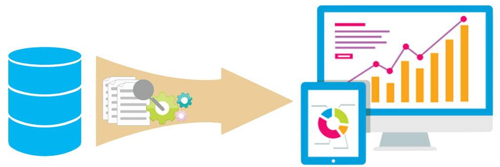

## Seeing is believing

- Let us visit [the Posit Shiny Gallery](https://shiny.posit.co/r/gallery/)

## Hello Shiny!

```r
# Load the Shiny library
library("shiny")

# Define the User Interface (Frontend)
ui <- fluidPage(
  titlePanel("Hello Shiny!"),
  sidebarLayout(
    sidebarPanel(
      sliderInput(inputId = "bins",
                  label = "Number of bins:",
                  min = 1,
                  max = 50,
                  value = 30)
    ),
    mainPanel(
      plotOutput(outputId = "distPlot")
    )
  )
)

# Define the Server (Backend)
server <- function(input, output) {
  output$distPlot <- renderPlot({
    x <- faithful$waiting
    bins <- seq(min(x), max(x), length.out = input$bins + 1)
    hist(x, breaks = bins, col = "#75AADB", border = "white",
         xlab = "Waiting time to next eruption (in mins)",
         main = "Histogram of waiting times")
  })
}

# Launch the shiny app
shinyApp(ui = ui, server = server)
```

*Note: the use of `$` is to access items of an object in base R (in the `tidyverse` we use the `pull` function)*

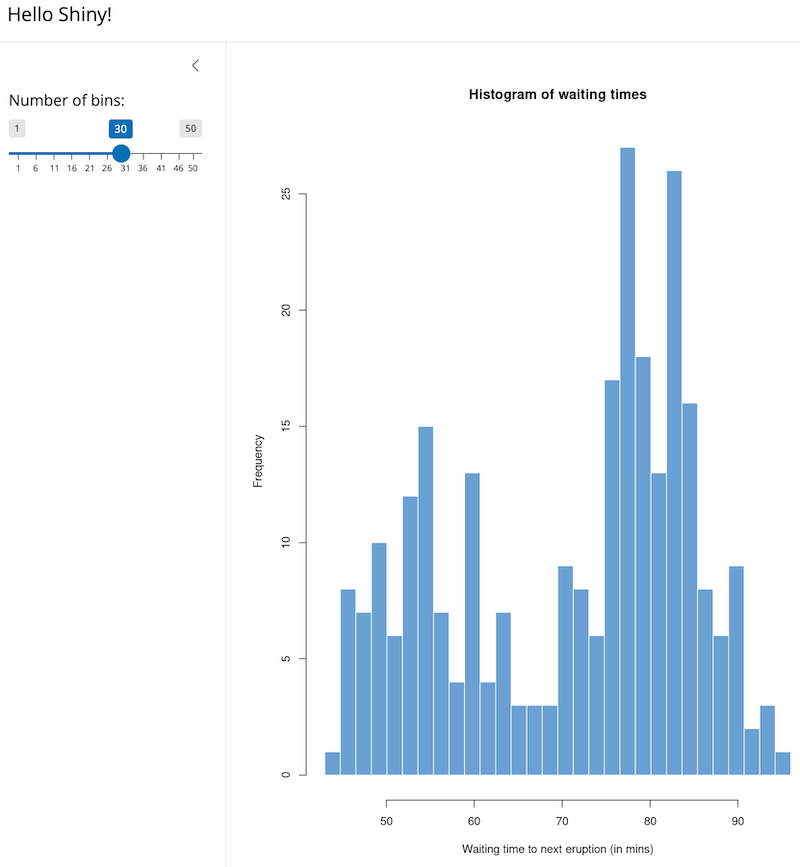

## Frontend vs. backend

**Frontend**

- This is where the user interacts with your app
- Chooses arguments to function parameters
- Choices are *requests*

**Backend**

- This is where the computations are made in response to the user’s choices
- Chosen arguments are passed to function parameters, producing an output
- The output is the *response*

*This frontend-to-backend continuous communication is key!*

## Frontend vs. backend

**Frontend**

```r
ui <- fluidPage(
  titlePanel("Hello Shiny!"),
  sidebarLayout(
    sidebarPanel(
      sliderInput(inputId = "bins",
                  label = "Number of bins:",
                  min = 1,
                  max = 50,
                  value = 30)
    ),
    mainPanel(
      plotOutput(outputId = "distPlot")
    )
  )
)
```

- The `sliderInput` has a specific `inputId` set to `"bins"`

**Backend**

```r
server <- function(input, output) {
  output$distPlot <- renderPlot({
    x <- faithful$waiting
    bins <- seq(min(x), max(x), length.out = input$bins + 1)
    hist(x, breaks = bins, col = "#75AADB", border = "white",
         xlab = "Waiting time to next eruption (in mins)",
         main = "Histogram of waiting times")
  })
}
```

- `inputId` from the `sliderInput` set to `"bins"` exists in the variable `input`

## Frontend vs. backend

**Frontend**

```r
ui <- fluidPage(
  titlePanel("Hello Shiny!"),
  sidebarLayout(
    sidebarPanel(
      sliderInput(inputId = "bins",
                  label = "Number of bins:",
                  min = 1,
                  max = 50,
                  value = 30)
    ),
    mainPanel(
      plotOutput(outputId = "distPlot")
    )
  )
)
```

- The `plotOutput()` has a specific `outputId` where we can name the `distPlot` we defined in the `server()`-function

**Backend**

```r
server <- function(input, output) {
  output$distPlot <- renderPlot({
    x <- faithful$waiting
    bins <- seq(min(x), max(x), length.out = input$bins + 1)
    hist(x, breaks = bins, col = "#75AADB", border = "white",
         xlab = "Waiting time to next eruption (in mins)",
         main = "Histogram of waiting times")
  })
}
```

- The plot in the `server`-function is saved in the special variable `output`, which is sent back to the `ui` and can be used as `outputId`

## Frontend vs. backend

[figure not shown]

## Defining the Input

Shiny comes with several `*Input()` functions used for different kinds of input:

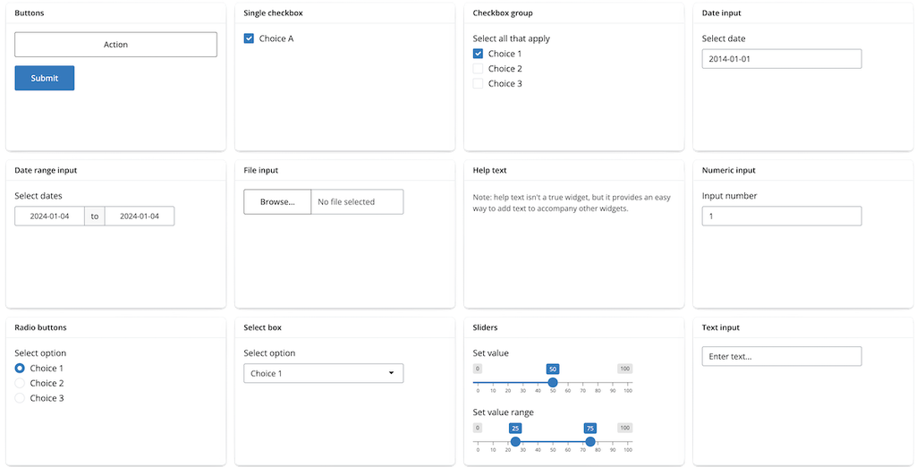

## Defining the Input

Shiny comes with several `*Input()` functions used for different kinds of input:

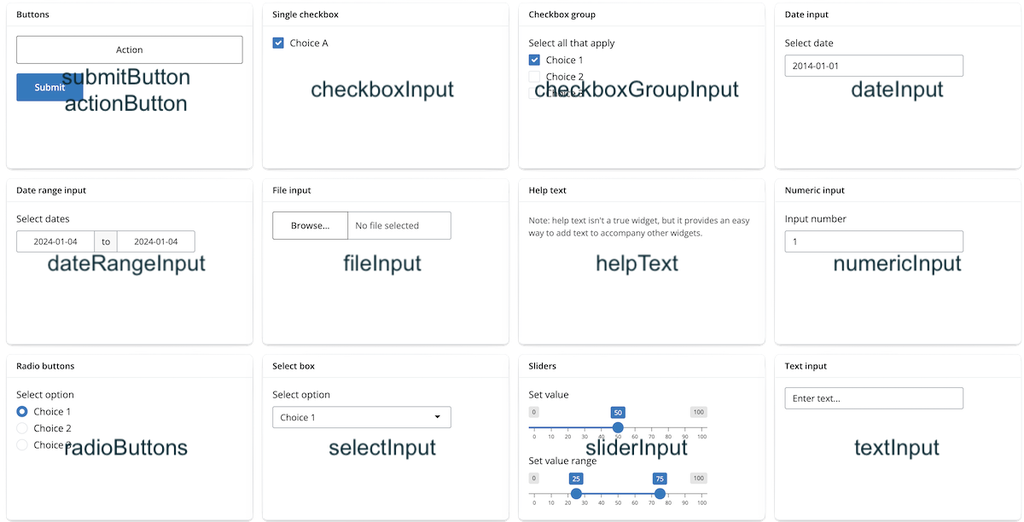

## Defining the Output

| Output function | Creates |
| --- | --- |
| dataTableOutput | DataTable |
| htmlOutput | raw HTML |
| imageOutput | image |
| plotOutput | plot |
| tableOutput | table |
| textOutput | text |
| uiOutput | raw HTML |
| verbatimTextOutput | text |

## Reactive versus Event Driven

### Event-Driven

*The app is only updated, when the user clicks a button*

- Controlled updates after all choices have been made
- Gives an overall better performance
- May seem old-fashioned to some users
- Works better with larger data

### Reactive

*The app is automatically updated, when a user chooses an option*

- Real-time Updates
- More simple interaction
- Improved User Experience
- Performance Overhead
- Works best with smaller data

*Today, we will work with creating a reactive app*

## In essence…

[figure not shown]

*Once you get your head around the syntax and functionality of the Shiny, it’s no longer about what you can build, but what you should build. Dashboards only have value, if they create value!*

## Summary

- Shiny facilitates the creation of reactive applications where the analysis becomes interactive
- Provides a user interface for dynamic data interaction
- Connects non-data literate professionals directly to the data
- Fully customisabled
- Used in production across industries!

[figure not shown]

## Once more unto the breach, dear friends, once more!

- Break and then the very last exercises of this year’s R for Bio Data Science course!

[figure not shown]

[figure not shown]